# Workflow: Interpreting hematological disease in light of a healthy reference

Sergio Triana & Lars Velten

06/05/2021

## Goals

Goals of this notebook are

- To automate the annotation of hematological disease samples in single cell RNA-seq
- to identify shifts in cell state and cell type frequency caused by disease
- to identify cell state specific and global changes in gene expression caused by disease
- to quantify the degree of inter-patient heterogeneity

## Preparation of data

First, you need a Seurat object containign a well annotated reference of cell states encountered in blood and bone marrow. We recommend ours :-)

```r
#LV: replace by fisgshare
load("/users/lvelten/project/AML/gene_expression/data/Sergio_figshare/mainData.rda")
Healthy <- subset(BM_All,subset = Batch %in% c("AML1","AML2","AML3","Q59"),invert=T)
rm(BM_All)
```

Second, you need a count matrix of your data. If your goal is to perform differential expression testing and to identify genes expressed, e.g., in diseased HSCs but not in healthy HSCs, you **absolutely need your own healthy controls**. **You cannot compare your disease samples to our healthy samples, since there will *always* be study specific batch effects**.

To demonstrate this usecase, in the following we treat our entire dataset as new, un-annotated data. That is, we map both the healthy individuals and the leukemic individuals back to the reference. If you want to run this workflow on your own data, just replace the seurat object `merged` with your own seurat object containing both healthy and diseased individuals. Besides this, you only need a csv file containing patient-level metadata and you're good to go. Note the comments in the code below.

If you want to run this vignette to reproduce the results from our manuscript 1:1, the original annotation for the healthy samples should be used, which you can acheive by setting `reproduce` to `TRUE`.

```r
reproduce <- FALSE
```

```r
#LV: replace by figshare
AMLs <- readRDS("/users/lvelten/project/AML/gene_expression/data/Sergio_figshare/AMLs_Scano_projected.rds")

#replace this line by a command that loads your seurart object. To make sure you use the same normalization that we use , run Seurat normalization. In this case, the antibody counts are CLR normalizaed and the RNA counts were Log Normalized.
#The object needs to have a metadata column Batch that encodes sample identity
 if (!reproduce) {
   merged <- merge(Healthy, y = AMLs, add.cell.ids = c("reference", "query"), project = "abAML")
 } else {
   merged <- AMLs
 }
#by

normalized_counts <- GetAssayData(merged, assay = "BOTH", slot="data")
counts <- GetAssayData(merged, assay = "BOTH", slot="counts")

#replace this line by a command that loads you patient-level meta data
#(row names should correspond to the Batch IDs used in the cell-level meta data, and there should be a column called Status that determines if the individuals are "healthy" or "diseased")
patient.metadata <- read.table("metadata.tsv", sep="\t",header=T,row.names=1)

merged$status <- patient.metadata[as.character(merged$Batch),"Status"]
```

## Mapping healthy data on reference data

Importantly, the projection only uses a set 462 genes that were selected to maximize information about cell states in the bone marrow. For differential expression testing (below), you can of course make use of all the genes sufficiently covered in your assay.

```r
counts.projection <- normalized_counts[intersect(rownames(normalized_counts), rownames(Healthy)),]
```

Next we use the routines from the `scmap` package to identify the nearest neighbors between your data (`counts.projection`) and our reference data (`Healthy`). This computation can take a while, several hours in the case of large datasets with 10,000s of cells.

```r
#set up query data
sce_Culture <- SingleCellExperiment(assays = list(normcounts =  as.matrix(counts.projection)))
logcounts(sce_Culture) <- normcounts(sce_Culture)
rowData(sce_Culture)$feature_symbol <- rownames(sce_Culture)

sce_All <- SingleCellExperiment(assays = list(normcounts = as.matrix(Healthy@assays$BOTH@data[rownames(counts.projection),])))

logcounts(sce_All) <- normcounts(sce_All)
# use gene names as feature symbols
rowData(sce_All)$feature_symbol <- rownames(sce_All)
# remove features with duplicated names
sce_All <- sce_All[!duplicated(rownames(sce_All)), ]

sce_Culture<-setFeatures(sce_Culture,features =  rownames(sce_Culture))
sce_Culture <- indexCell(sce_Culture)

sce_All<-setFeatures(sce_All,features =  rownames(sce_All))
sce_All <- indexCell(sce_All)


Culture_Map <- scmapCell(
  projection = sce_Culture,
  index_list = list(
    sce_All = metadata(sce_All)$scmap_cell_index
  ),
  w = 5)

#it makes sense to save the result
```

Finally, we use the nearest neighbor information to compute the embedding of your cells in a the umap, to identify the most similar cell type, and to compute a score that determines how similar each query cell is to the reference.

```r
Calc<-function(id,cult){
  u <- cult[,id]
  xcoords <- Healthy@reductions$MOFAUMAP@cell.embeddings[,1][u]
  ycoords <- Healthy@reductions$MOFAUMAP@cell.embeddings[,2][u]
  x=mean(xcoords)
  y=mean(ycoords)
  ct.t=table(Idents(Healthy)[u])
  ct.t<- ct.t[order(ct.t,decreasing = T)]
  nearest <- Healthy@assays$BOTH@data[rownames(sce_Culture),u]
  query <- normcounts(sce_Culture)[,id]
  cornn<- apply(nearest,2,function(x) cor(x, query))
  data.frame(row.names = id, x = x, y =y, ct = names(ct.t)[1], score = mean(cornn))

}


library(parallel)
mapped <- mclapply(colnames(Culture_Map$sce_All[[1]]), Calc, cult = Culture_Map$sce_All[[1]], mc.cores = 6)

mapped <- do.call(rbind,mapped)

Idents(merged) <- mapped$ct
mapped$sample <- merged$Batch
```

## Quantifying shifts in cell state frequency

You can then quantify how often each cell type occurs in each of your samples and group samples by cell state abundance. For this example, we remove rare cell types and lymphpoid cells, since we are interested in the differentiation state of AML blasts, and not in the degree of immune infiltration. However, in your scenario a different (or no ) selection of cell types may be preferred!

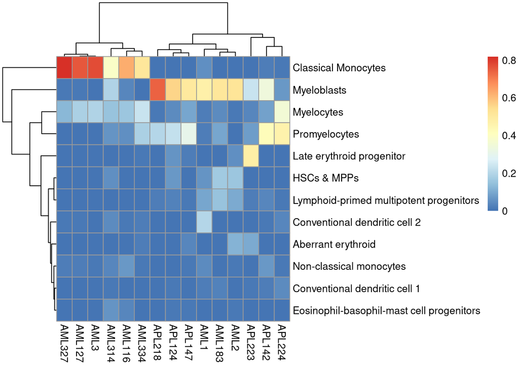

[figure not shown]

```r
mapped_amls <- subset(mapped, sample %in% rownames(patient.metadata)[patient.metadata$Status == "diseased"])

forcluster <- table(as.character(mapped_amls$ct), as.character(mapped_amls$sample))

#the following line needs to be modified to include only
forcluster <- forcluster[apply(forcluster,1,sum)> 100 & !grepl("T cell|NK cell|B cell", rownames(forcluster)),]
forcluster <- t(t(forcluster)/apply(forcluster,2,sum))

cl <- pheatmap::pheatmap(forcluster, clustering_method = "ward.D2")
```

## Identifying cell state specific differential gene expression

We use DESeq2 for differential expression testing and treat each cell type from each patient as a bulk sample. DESeq2 empirically estimates sample-to-sample variance: When comparing between samples, batch-to-batch noise is more important to account for than the specific distributional properties of single cell RNA-seq data.

We require a cell type to be represented withat least 20 cells in a sample for that sample to enter the comparison. The test we use accounts for patient age and gender as a covariate. Please adjust the code below to your patient/sample-level covariates.

```r
if (reproduce) {
  Healthy$status <- "healthy"
  merged <- merge(Healthy, y = merged, add.cell.ids = c("reference", "query"), project = "abAML")
}

cat("Samples included into DE comparison (min 20 cells per sample):\n")
```

```
## Samples included into DE comparison (min 20 cells per sample):
```

```r
getTest <- function(id, assay = "AB") {
  ab <- GetAssayData(merged, assay = assay, slot = "counts")

  summed <-sapply(unique(merged$Batch), function(btc) {
    use <- merged$Batch == btc & Idents(merged)  == id
    if (sum(use)==1) ab[,merged$Batch  == btc &Idents(merged)  == id] else if (sum(use)==0) rep(0, nrow(ab)) else apply(ab[,merged$Batch  == btc &Idents(merged)  == id],1,sum)
  })
  ncells <- sapply(unique(merged$Batch), function(btc) sum(merged$Batch == btc & Idents(merged) == id))
  rownames(summed) <- rownames(ab)
  sums <- apply(summed,2,sum)
  summed <- summed[,ncells > 20]
  cat(id, ":", paste(colnames(summed),collapse = ","),"\n")

  #adjust to include your cavariates
  dds <- data.frame(row.names = colnames(summed),
                    individual =colnames(summed),
                    status = factor(patient.metadata[colnames(summed),"Status"]),
                    age = scale(patient.metadata[colnames(summed),"Age"]),
                    gender = factor(patient.metadata[colnames(summed),"Gender"]))

  statuscounts <- table(dds$status)
  runaml <- statuscounts["diseased"] > 2 & statuscounts["healthy"] > 2

  tryCatch(
    {
   if (runaml) {
     #adjust to include your covariates
     deseq <- DESeqDataSetFromMatrix(summed, dds, ~  status + age + gender )
     deseq <- estimateSizeFactors(deseq)
     deseq <- estimateDispersions(deseq)
     deseq <- nbinomWaldTest(deseq)
     results <- as.data.frame(results(deseq, contrast = c("status","healthy","diseased")))
     results$gene <- rownames(results)
     results$ct <- id
     results$nAML <- statuscounts["diseased"]
     results$nHealthy <- statuscounts["healthy"]
     aml <- T

     return(results)
   } else return(NULL)




    }, error = function(e) {warning("In ", id, e); NULL}
  )

}

#if you want to look at RNA differential expression, replace assay by RNA
 all.tests.covariate <- lapply(unique(as.character(Idents(merged) )), getTest, assay="AB")
```

```
## Plasma cells : Aged2,Aged1,Aged3,BM2,BM3,BM1,APL223
## Late erythroid progenitor : Aged2,Aged1,Aged3,BM2,BM3,BM1,AML2,APL223
## Conventional dendritic cell 1 : Aged2,Aged1,Aged3,BM2,BM3,BM1,AML1,AML183
## Pre-B cells : Aged2,Aged1,Aged3,BM2,BM3,BM1
## Pro-B cells : Aged2,Aged3,BM2,BM3,BM1
## Aberrant erythroid : Aged3,BM3,AML2
## Conventional dendritic cell 2 : Aged2,Aged1,Aged3,BM2,BM3,BM1,AML1,AML3
## Myelocytes : Aged3,BM2,BM3,BM1,AML1,AML2,AML3,APL147,AML183,AML127,AML334,AML327,APL142,AML314,AML116,APL224
## Early erythroid progenitor : Aged2,Aged1,Aged3,BM2,BM3,BM1
## Lymphoid-primed multipotent progenitors : Aged2,Aged1,Aged3,BM2,BM3,BM1,AML1,AML2,AML3,AML183
## Plasmacytoid dendritic cell progenitors : Aged3,BM2,BM3,BM1
## Megakaryocyte progenitors : Aged1,Aged3,BM2,BM3,BM1,AML1
## Non-classical monocytes : Aged2,Aged1,Aged3,BM2,BM3,BM1,AML1,AML2,AML3,AML127,AML327,APL142,AML116
## Classical Monocytes : Aged1,Aged3,BM2,BM3,BM1,AML1,AML2,AML3,AML127,AML334,AML327,AML314,AML116
## Myeloblasts : Aged2,Aged1,Aged3,BM2,BM3,BM1,AML1,AML2,AML3,APL124,APL223,APL147,AML183,APL142,AML314,APL218,APL224
## CD4+ memory T cells : Aged2,Aged1,Aged3,BM2,BM3,BM1,AML1,AML2,AML3,APL124,APL223,APL147,AML327,AML116
## Promyelocytes : Aged3,BM2,BM3,BM1,AML1,APL124,APL147,AML183,AML334,APL142,APL218,AML116,APL224
## Plasmacytoid dendritic cells : Aged2,Aged1,Aged3,BM2,BM3,BM1
## Nonswitched memory B cells : Aged2,Aged1,Aged3,BM2,BM3,BM1,AML1,AML2,AML3
## HSCs & MPPs : Aged2,Aged1,Aged3,BM2,BM3,BM1,AML1,AML2,AML3,AML183
## CD8+ effector memory T cells : Aged2,Aged1,Aged3,BM2,BM3,BM1,AML2,AML3,APL224
## Mature naive B cells : Aged2,Aged1,Aged3,BM2,BM3,BM1,AML2,APL124,APL223,APL218
## CD8+CD103+ tissue resident memory T cells : Aged2,Aged1,Aged3,BM2,BM3,BM1,AML2,AML3,APL124,APL223
## CD56brightCD16- NK cells : Aged3,BM2,BM3,BM1
## Class switched memory B cells : Aged2,Aged1,Aged3,BM2,BM3,BM1,AML2
## CD8+ central memory T cells : Aged2,Aged1,Aged3,BM2,BM3,BM1,AML1,AML2,AML3,APL223
## CD11c+ memory B cells : BM2,BM1
## GammaDelta T cells : Aged2,Aged1,Aged3,BM2,BM3,BM1,AML2,AML3
## CD56dimCD16+ NK cells : Aged2,Aged1,Aged3,BM2,BM3,BM1,AML2,AML3,APL124,APL147,APL224
## CD4+ naive T cells : Aged2,Aged1,Aged3,BM2,BM3,BM1,AML2,AML3,APL124
## Immature B cells : Aged2,Aged3,BM2,BM3,BM1
## CD8+ naive T cells : Aged2,Aged1,BM2,BM3,BM1,AML2,AML3,APL124,APL223
## CD4+ cytotoxic T cells : Aged1,Aged3,BM2,BM1,AML2,AML3,APL224
## CD69+PD-1+ memory CD4+ T cells :
## NK T cells : Aged1,BM2
## Small pre-B cell :
## Erythro-myeloid progenitors : Aged3,BM2,BM3,BM1,AML1
## Pre-pro-B cells :
## Monocyte-like blasts :
## Eosinophil-basophil-mast cell progenitors : BM2,BM3,BM1,AML2
## NK cell progenitors :
## Mesenchymal cells_65_1 :
## Immature-like blasts :
## Mesenchymal cells_65_2 :
## Dendritic-like blasts :
```

```r
  all.tests.covariate <- do.call(rbind, all.tests.covariate)
```

This results in a table of differtentially expressed genes per cell type.

```r
head(all.tests.covariate)
```

```
##            baseMean log2FoldChange     lfcSE         stat      pvalue      padj
## B7.H4-AB  2112.5980    0.088434318 0.2439825  0.362461753 0.717007000 0.9558852
## CD10-AB    352.5569   -0.180752141 0.5028976 -0.359421331 0.719279919 0.9558852
## CD103-AB   644.2413   -0.971909647 0.6805836 -1.428053193 0.153276549 0.4553215
## CD117-AB  2047.8113   -1.566771368 0.6013790 -2.605297618 0.009179449 0.1043621
## CD11a-AB 42448.7142   -0.120979078 0.7139356 -0.169453780 0.865439724 0.9712157
## CD11b-AB 11632.3701   -0.001785985 0.7933554 -0.002251179 0.998203820 0.9982038
##              gene         ct nAML nHealthy
## B7.H4-AB B7.H4-AB Myelocytes   12        4
## CD10-AB   CD10-AB Myelocytes   12        4
## CD103-AB CD103-AB Myelocytes   12        4
## CD117-AB CD117-AB Myelocytes   12        4
## CD11a-AB CD11a-AB Myelocytes   12        4
## CD11b-AB CD11b-AB Myelocytes   12        4
```

## Identifying inter-patient variability

To identify genes with a particularly high degree of patient to patient variability, we for each cell type train random forest classifiers to predict sample from gene expression. Genes with a particularly high importance to this classifier are sample specific. We excluded healthy samples from this to look at patient-to-patient variability.

```r
AMLs <- subset(merged, status == "diseased")
Healthy <- subset(merged, status != "diseased")

#train RF
getRF <- function(ct) {
  AMLs.myeloid <- subset(AMLs, idents = ct)
  ab <- GetAssayData(AMLs.myeloid, assay = "AB", slot = "counts")
  ncells <- sapply(unique(AMLs.myeloid$Batch), function(btc) sum(AMLs.myeloid$Batch== btc & Idents(AMLs.myeloid) == ct))

  usepat <- unique(AMLs.myeloid$Batch)[ncells>20] #same fitlering criterion as above
  if (length(usepat) <= 2) return(NULL)
  AMLs.myeloid <- subset(AMLs.myeloid, Batch %in% usepat)
  pat <- factor(AMLs.myeloid$Batch)
  pred <- t(GetAssayData(AMLs.myeloid, "AB", slot = "data"))

  if (length(unique(pat)) > 1) {
    rf <- randomForest(as.matrix(pred), y = pat, importance = T)
    data.frame(row.names = rownames(rf$importance), ct = ct, gene = rownames(rf$importance),
               MeanDecreaseAccuracy = rf$importance[,"MeanDecreaseAccuracy"],
               MeanDecreaseGini = rf$importance[,"MeanDecreaseGini"],
               MeanDecreaseAccuracySD = rf$importanceSD[,"MeanDecreaseAccuracy"],
              norm =  rf$importance[,"MeanDecreaseAccuracy"] / max(rf$importance[,"MeanDecreaseAccuracy"]))
  } else NULL


}

ct <- Idents(AMLs)
usect <- table(ct)
usect <- names(usect)[usect > 10]

 rfs <- lapply(usect, getRF)
 rfs <- do.call(rbind, rfs)
```

## Final plots

Finally we make plots that display the differential expression and the sample to sample variability:

```r
showcelltypes <- c("HSCs & MPPs", "Myelocytes")
usecounts.AMLs <- GetAssayData(AMLs, assay = "AB", slot="counts")
usecounts.Healthy <- GetAssayData(Healthy, assay = "AB", slot="counts")
```

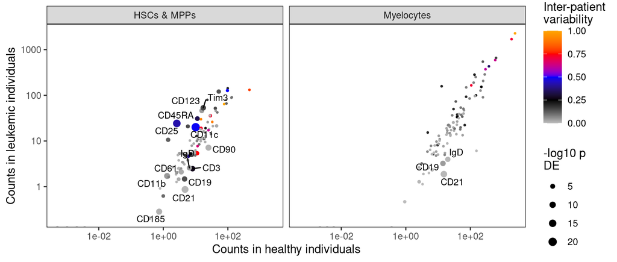